# Notebook

### Introduction

In this project, we look at the NYC Subway data and figure out if more people ride the subway when it is raining versus when it is not raining.

### Tools and Data

We load the python libaries for the project:

```python
import pandas as pd
import numpy as np
import scipy
import scipy.stats
import matplotlib.pyplot as plt
#import matplotlib.mlab as ml
import statsmodels.api as sm
#from sklearn.decomposition import PCA
#from statsmodels.sandbox.regression.predstd import wls_prediction_std
from scipy import stats
```

We wrangled NYC Subway data and Weather data in the Intro to Data Science class. We load the ready to use data set from the csv file into a pandas DataFrame instance.

```python
datafile = 'D:/myPython/Data_Science_Project1/improved-dataset/improved-dataset/turnstile_weather_v2.csv'
#datafile = 'D:/myPython/turnstile_data_master_with_weather.csv'
df = pd.read_csv(datafile)
print "The number of entries in the data set is: %d" % len(df)
```

```
The number of entries in the data set is: 42649
```

### Section 1. Statistical Test

Explore the diference between hourly entries when it is rain versa it is no rain. First, we test the null hypothesis that the distribution of hourly entries is Gaussian. We use D’Agostino and Pearson’s test for normality:

```python
(k2,p) = scipy.stats.normaltest(df['ENTRIESn_hourly'], axis=0)
print "p-value for normality test is: %f" % p
```

```
p-value for normality test is: 0.000000
```

It means that the distribution of hourly entries is highly unlikely Gaussian.

Compute descriptive statistics for samples with and without rain:

```python
with_rain = df['ENTRIESn_hourly'][df.rain == 1]
without_rain = df['ENTRIESn_hourly'][df.rain == 0]
df1 = pd.DataFrame([scipy.stats.describe(with_rain),scipy.stats.describe(without_rain)],\
                       index = ['rain','no rain'],columns = ['samples','min, max','mean','varianse','skeweness','kurtosis'])
print df1
#plt.figure()
#(df['ENTRIESn_hourly']).plot()
```

```
         samples        min, max         mean         varianse  skeweness  \
rain        9585  (0.0, 32289.0)  2028.196035  10172485.240051   3.956968
no rain    33064  (0.0, 32814.0)  1845.539439   8287321.595154   4.031911

         kurtosis
rain     21.98662
no rain  23.40452
```

The distributions look different.  
We will estimate whether the distributions are different. hourly entries is highly unlikely Gaussian so we will use nonparamertic Mann-Whitney U-Test. We test the null hypothesis that two populations are the same. As the reported p-value is for a one-sided hypothesis, to get the two-sided p-value we multiply the returned p-value by 2:

```python
(U,p) = scipy.stats.mannwhitneyu(with_rain, without_rain, use_continuity=True)
print "U-statistic for Mann-Whitney U-Test is: %f" % U
#print "p-value for Mann-Whitney U-Test is: %f" % p
# As the function returns p = nan, we compute p from U:
m_u = len(with_rain)*len(without_rain)/2
sigma_u = np.sqrt(len(with_rain)*len(without_rain)*(len(with_rain)+len(without_rain)+1)/12)
z = (U - m_u)/sigma_u
p = 2*scipy.stats.norm.cdf(z)
print "p-value for Mann-Whitney U-Test is: %f" % p
```

```
U-statistic for Mann-Whitney U-Test is: 153635120.500000
p-value for Mann-Whitney U-Test is: 0.000005
```

As p-value is very small, we reject the null hypothesis. Therefore the alternative hypothesis that **dictributions of ridership in the rain and no rain samples are different** is statistically significant.

The mean for the rain data is bigger then the mean for the no rain data. We test the null hypothesis that the population means for rain samples and no rain samples are equal. As we have a plenty of samples, we can apply Welch's t-test. We use a one-tailed test to check the hypothesis that mean for samples with rain is larger then one without rain. We need to use p/2 value and check if t > 0.

```python
(t,p) = scipy.stats.ttest_ind(df['ENTRIESn_hourly'][df.rain == 1], df['ENTRIESn_hourly'][df.rain == 0], axis=0, equal_var=False)
print "t-statistic for Welch's t-test is: %f" % t
print "p-value for Welch's t-test is: %f" % p
```

```
t-statistic for Welch's t-test is: 5.042883
p-value for Welch's t-test is: 0.000000
```

As p-value is much less then any reasonable threshold the null hypothesis of equality of means is highly unlikely. Therefore, the alternative hypothesis that **mean of the ridership in the rain is bigger then one without rain** is statistically significant.

### Section 2. Linear Regression

We split the data into training and testing sets. We randomly sample 70% of data as the training set. The rest 30% data are the testing set. We will build a linear regression model using Statsmodels OLS in the train set and estimate the model in the test set.

```python
np.random.seed(53)
is_idx = np.random.sample(len(df)) < 0.7
```

Choose features for regression. We will rely on intuition first, and will backwardly delete variables to increase R-squared criteria. Obviously, ridership depends on the station (unit), time (hour), weather conditions (conds) and day of week. 'rain' feature is binary. It means that regardless other input variables, output increase by const + 'rain' coefficient, if it is rain, and by const otherwise.

```python
#df.squared_tempi = np.square(df.tempi**2)

features = df[['rain', 'precipi','tempi']]

#features = (features - features.mean()) / features.std()

features = sm.add_constant(features)
# Add dummy variables
dummy_units1 = pd.get_dummies(df['UNIT'], prefix='unit')
dummy_units2 = pd.get_dummies(df['hour'], prefix='hour')
dummy_units3 = pd.get_dummies(df['conds'], prefix='conds')
dummy_units4 = pd.get_dummies(df['day_week'], prefix='day_week')

features = features.join([dummy_units1,dummy_units2,dummy_units3,dummy_units4])

#pca = PCA(n_components=0.9)
#features = pca.fit_transform(features)

values = df['ENTRIESn_hourly']
#values = (values - values.mean()) / values.std()
```

```python
model = sm.OLS(values[is_idx],features[is_idx])
results = model.fit()
print results.summary()
```

```
                            OLS Regression Results
==============================================================================
Dep. Variable:        ENTRIESn_hourly   R-squared:                       0.554
Model:                            OLS   Adj. R-squared:                  0.550
Method:                 Least Squares   F-statistic:                     139.1
Date:                Tue, 17 Mar 2015   Prob (F-statistic):               0.00
Time:                        17:11:31   Log-Likelihood:            -2.6946e+05
No. Observations:               29869   AIC:                         5.395e+05
Df Residuals:                   29604   BIC:                         5.417e+05
Df Model:                         264
==========================================================================================
                             coef    std err          t      P>|t|      [95.0% Conf. Int.]
------------------------------------------------------------------------------------------
const                   2358.0803     91.843     25.675      0.000      2178.065  2538.096
rain                      45.9997     37.203      1.236      0.216       -26.920   118.920
precipi                -4140.6340    914.731     -4.527      0.000     -5933.547 -2347.721
tempi                    -18.6069      1.809    -10.288      0.000       -22.152   -15.062
unit_R003              -1731.7466    182.879     -9.469      0.000     -2090.197 -1373.297
unit_R004              -1397.7934    181.442     -7.704      0.000     -1753.427 -1042.160
unit_R005              -1315.0270    175.913     -7.475      0.000     -1659.825  -970.229
unit_R006              -1164.7471    173.283     -6.722      0.000     -1504.389  -825.105
unit_R007              -1546.0432    180.751     -8.553      0.000     -1900.322 -1191.764
unit_R008              -1537.3269    180.011     -8.540      0.000     -1890.156 -1184.498
unit_R009              -1428.1410    183.704     -7.774      0.000     -1788.210 -1068.072
unit_R011               5796.9699    180.430     32.129      0.000      5443.319  6150.620
unit_R012               7139.1143    174.931     40.811      0.000      6796.242  7481.987
unit_R013                702.9652    176.928      3.973      0.000       356.179  1049.751
unit_R016               -974.7068    177.605     -5.488      0.000     -1322.820  -626.594
unit_R017               2507.1244    181.158     13.839      0.000      2152.046  2862.203
unit_R018               6040.8030    179.232     33.704      0.000      5689.501  6392.105
unit_R019               1549.1820    172.105      9.001      0.000      1211.849  1886.515
unit_R020               4870.5310    181.909     26.775      0.000      4513.981  5227.080
unit_R021               2825.0601    174.268     16.211      0.000      2483.487  3166.633
unit_R022               8422.1230    182.652     46.110      0.000      8064.117  8780.129
unit_R023               4701.7235    179.701     26.164      0.000      4349.501  5053.946
unit_R024               1610.4068    183.673      8.768      0.000      1250.400  1970.414
unit_R025               3841.2074    173.916     22.087      0.000      3500.325  4182.090
unit_R027               1303.1172    179.730      7.250      0.000       950.839  1655.395
unit_R029               5923.0115    180.460     32.822      0.000      5569.303  6276.720
unit_R030               1231.2241    172.369      7.143      0.000       893.373  1569.075
```

[output cut: 237 more lines]

```
day_week_2               681.8457     34.037     20.032      0.000       615.131   748.561
day_week_3               701.2275     32.438     21.617      0.000       637.647   764.808
day_week_4               662.2279     32.716     20.242      0.000       598.103   726.352
day_week_5              -197.9380     33.896     -5.840      0.000      -264.376  -131.500
day_week_6              -561.8057     29.757    -18.880      0.000      -620.130  -503.481
==============================================================================
Omnibus:                    20561.111   Durbin-Watson:                   1.856
Prob(Omnibus):                  0.000   Jarque-Bera (JB):           703489.532
Skew:                           2.866   Prob(JB):                         0.00
Kurtosis:                      26.074   Cond. No.                          nan
==============================================================================

Warnings:
[1] The smallest eigenvalue is -6.93e-11. This might indicate that there are
strong multicollinearity problems or that the design matrix is singular.
```

R-squared = 0.554 for this model.

While the regression coefficient at 'rain' is positive, the p-value is big enough to be regected. However, the 'conds' coefficients at the 'rainy' inputs are much bigger then at the 'conds_Clear' input and 'conds_Rain' is statistically significant at 5% threshold.

Since F-statistics is far larger than 1, it provides the evidence against the null hypothesis, that ENTRIESn_hourly does not depend on input variables.

The 'rush time' coefficients are much bigger then the 'night time' ones. The same holds for the working days versa holidays coefficients. The reasonable relations between the coefficients support the intuition.

Next, we predict the results applying the model to the test set:

```python
pred = model.predict(results.params,features[~is_idx])

r_squared = 1 - np.sum((values[~is_idx] - pred)**2) / np.sum((values[~is_idx] - np.mean(values[~is_idx]))**2)
print "R-squared for the test set is: %f" % r_squared
res_std = np.std((values[~is_idx] - pred))
print "std of the residuals for the test set is: %f" % res_std
err = values[~is_idx] - pred
#%pylab inline
#plt.figure()
#err.hist(bins=50)
```

```
R-squared for the test set is: 0.526724
std of the residuals for the test set is: 1953.040935
```

R-squared for the test set is about the same as one for the train set (0.554 vs 0.527). It means the model we've built is pretty robust. In spite of the moderate value of the R-squared we can use the model

```python
(k2,p) = scipy.stats.normaltest(err, axis=0)
print "p-value for normality test is: %f" % p
```

```
p-value for normality test is: 0.000000
```

The residuals did not pass the normality test. It means the linear regression model has a high bias. We could try polinomial features or use nonlinear models, but it is out of the scope of a given research.

```python
#residuals plot
#plt.figure()
#(values[~is_idx] - pred).plot()
```

### Section 3. Visualization

3.1 We plot tho histograms: one of ENTRIESn_hourly for rainy days and one of ENTRIESn_hourly for non-rainy days. We combine the two histograms in a single plot for visibility:

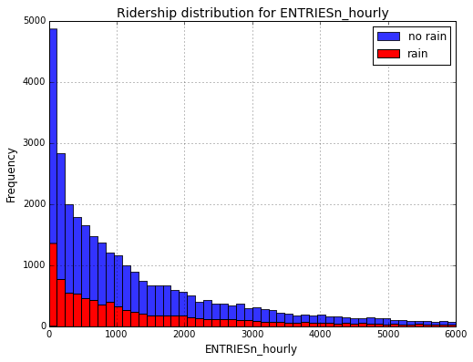

```python
    %pylab inline
    plt.figure(figsize = (8,6))
    without_rain.hist(bins=50,range = (0,6000),label = 'no rain',alpha = 0.8)
    with_rain.hist(bins=50,range = (0,6000),label = 'rain',color = 'r')

    #df['ENTRIESn_hourly'].hist(bins=30,range = (0,6000))
    plt.title('Ridership distribution for ENTRIESn_hourly', fontsize=14)
    plt.xlabel('ENTRIESn_hourly', fontsize=12)
    plt.ylabel('Frequency', fontsize=12)
    plt.legend()
```

From the histogram it is clear that the distributions are different. The tail of the rain distribution is more flat. No-rain distribution is much higher then rain one, because the frequency of no-rain data is much bigger then rain ones. Obviously, it is mostly clear. So it does not contadict to our result that the mean ridership for rainy data is bigger then one for non-rainy data.

3.2 Next, we create a visualization as a bar plot for the mean ridership by time-of-day, grouped by rain and no rain. Data is sampled with 4 hour interval, so ve have 6 periods for 4 hours.

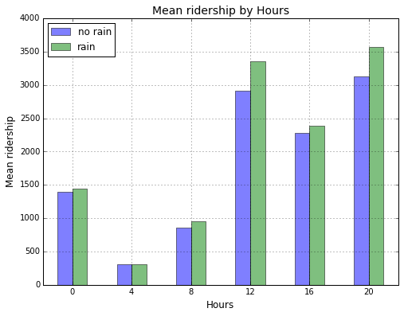

```python
hourly_norain_mean = without_rain.groupby(df['hour']).mean()
hourly_rain_mean = with_rain.groupby(df['hour']).mean()

df2 = pd.DataFrame({'no rain':hourly_norain_mean,'rain':hourly_rain_mean},columns=['no rain','rain'])
df2.plot(kind='bar',alpha = 0.5,figsize = (8,6))

plt.title('Mean ridership by Hours', fontsize=14)
plt.xlabel('Hours', fontsize=12)
plt.ylabel('Mean ridership', fontsize=12)
plt.xticks(arange(6),('0','4','8','12','16','20'),rotation=0)
plt.legend(loc = 2)
```

The visualization supports our conclusion about mean ridership: it is bigger for rainy data then for non-rainy data. Every pair except 0-4 hours one has higher 'rain' bar then'no rain' bar. Rush hour bars are higher then night bars as it should be.

### Section 4. Conclusion

4.1. From our analysis and interpretation of the data, we have got the following conclusions. **On average**, more people do ride the NYC subway when it is raining then it is not raining. But, in general, less people ride the NYC subway when it is raining then it is not raining, just because it is mostly clear in NYC. The ridership distributions are statistically different for raining and not raining cases. The mean of the ridership for raining cases is statistically bigger then the mean of the ridership for not raining cases.

4.2. We relied on statistical tests. In particular, we used nonparamertic Mann-Whitney U-Test for testing hypothesis that populations for raining and not raining cases are the same. Also we used Welch's one-tailed t-test to check the hypothesis that mean for samples with rain is equal to ones without rain. In both cases we regected the hypothesis. Therefore it is highly likely that distributions are different and the mean for samples with rain is bigger then for samples without rain.

The visualisation of mean ridership by hours also supports our conclusion that mean ridership is bigger for rainy cases then for non-rainy ones.

### Section 5. Reflection

5.1. We wrangled NYC Subway data and Weather data before, so the dataset is clean. The dependent variable is marked as 'ENTRIESn_hourly' in spite of the data is sampled by 4 hours intervals.

5.2. There are some shortcomings of the linear regression model we built: * The residuals of the model are not Gaussian. * The variance of residuals is not constant. * The smallest eigenvalue is -6.93e-11. This might indicate that there are strong multicollinearity problems or that the design matrix is singular.

### References

http://ipython.org/documentation.html

https://github.com/ipython/ipython/wiki/Cookbook%3A-Index

Rossant, Cyrille (2013), *Learning IPython for Interactive Computing and Data Visualization*, ''Packt Publishing''.

https://github.com/ipython/ipython/wiki/Cookbook%3A-Index

http://pandas.pydata.org/pandas-docs/stable/tutorials.html

http://docs.scipy.org/doc/scipy/reference/stats.html

Downey, Allen B. (2011), *Think Stats*, ''O’Reilly Media''.

McKinney, Wes (2013), *Python for Data Analysis*, ''O’Reilly Media''.

http://statsmodels.sourceforge.net/devel/examples/notebooks/generated/ols.html

James, Gareth; Witten, Daniela; Hastie, Trevor; Tibshirani, Robert (2013), *An Introduction to Statistical Learning with Applications in R*, ''Springer''.

http://matplotlib.org/api/pyplot_api.html